# Практикум по ANOVA и post hoc сравнениям

Liliya Golubnikova

2023-01-23

## Загрузка библиотек

## Загрузка и фильтрация данных

```r
soccer_general <- read.csv("../soccer.csv", sep=";")[, 2:6] %>%
    mutate(Position = as.factor(Position),
    Nationality = as.factor(Nationality),
    Age = as.numeric(Age),
    Height = as.numeric(Height)
) %>%
filter(Nationality %in% c("Spanish", "Italian", "German", "English", "Argentinian"))

set.seed(1)

soccer_wrk <- soccer_general[sample(1:nrow(soccer_general), 150), ] %>%
    mutate(Nationality = factor(Nationality))
```

## 1. Наличие связи между ростом футболиста и его позицией на поле

*Метод:* дисперсионный анализ.

*Гипотезы:*  
- H0: средние между группами идентичны  
- H1: среднее значение по крайней мере для одной группы отличается

### Сводная статистика:

```r
#Оценка кол-ва игроков в каждой позиции
#table(soccer_wrk$Position)

#Оценка среднего роста игрока в каждой позиции
#soccer_wrk %>%
#  select(`Height`, `Position`) %>%
#  group_by(`Position`) %>%
#  dplyr::summarise(across(where(is.numeric), function(x) mean(x, na.rm = TRUE)))

#Оценка стандартного отклонения роста игрока в каждой позиции
#soccer_wrk %>%
#  select(`Height`, `Position`) %>%
#  group_by(`Position`) %>%
#  dplyr::summarise(across(where(is.numeric), function(x) sd(x, na.rm = TRUE)))

soccer_wrk %>%
    group_by(Position) %>%
    summarise(
        count_position = n(),
        mean_time = mean(Height, na.rm = TRUE),
        sd_time = sd(Height, na.rm = TRUE)
    )
```

```
## # A tibble: 4 × 4
##   Position   count_position mean_time sd_time
##   <fct>               <int>     <dbl>   <dbl>
## 1 Defender               55      183.    4.98
## 2 Forward                30      182.    7.99
## 3 Goalkeeper             21      188.    5.08
## 4 Midfielder             44      179     5.65
```

### Box-plot для визуальной оценки данных

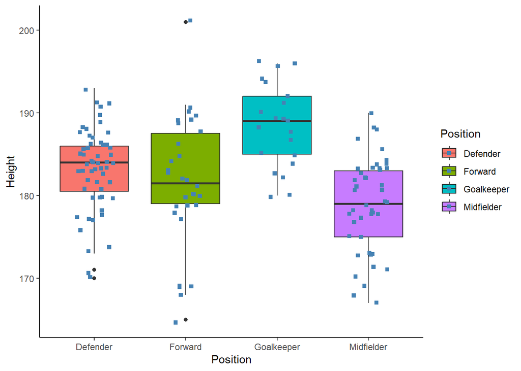

```r
ggplot(soccer_wrk, aes(x = Position, y = Height, fill = Position)) +
    geom_boxplot() +
    geom_jitter(shape = 15,
        color = "steelblue",
        position = position_jitter(0.21)) +
    theme_classic()
```

### One-way ANOVA

```r
#aov(formula, data)
#Arguments:
#- formula: The equation you want to estimate
#- data: The dataset used

#y ~ X1+ X2+...+Xn # X1 +  X2 +... refers to the independent variables
#y ~ . # use all the remaining variables as independent variables


anova_one_way <- aov(Height ~ Position, data = soccer_wrk)
summary(anova_one_way)
```

```
##              Df Sum Sq Mean Sq F value   Pr(>F)
## Position      3   1345   448.3   12.88 1.64e-07 ***
## Residuals   146   5082    34.8
## ---
## Signif. codes:  0 '***' 0.001 '**' 0.01 '*' 0.05 '.' 0.1 ' ' 1
```

**Вывод:**  
- `p-value` < 0.05 => существует статистическая разница между группами.

## Анализ методом Хоторна-Бретца-Вестфалла

*Для того, чтобы описать взаимосвязь между ростом футболиста и его положением на поле (p-values + доверительные интервалы).*

```r
#Tukey сигнализирует, что мы хотим сравнить каждую группу с каждой. Анализ выполняется не методом Тьюки, а методом Хоторна-Бретца-Вестфалла!

m0 <- lm(Height ~ Position, data = soccer_wrk)
HBW.comp <- m0 %>%  glht(linfct = mcp(Position = "Tukey"))


HBW.comp %>% summary()
```

```
##
##   Simultaneous Tests for General Linear Hypotheses
##
## Multiple Comparisons of Means: Tukey Contrasts
##
##
## Fit: lm(formula = Height ~ Position, data = soccer_wrk)
##
## Linear Hypotheses:
##                              Estimate Std. Error t value Pr(>|t|)
## Forward - Defender == 0        -1.718      1.339  -1.283  0.57141
## Goalkeeper - Defender == 0      5.258      1.513   3.474  0.00357 **
## Midfielder - Defender == 0     -4.218      1.193  -3.535  0.00296 **
## Goalkeeper - Forward == 0       6.976      1.679   4.156  < 0.001 ***
## Midfielder - Forward == 0      -2.500      1.397  -1.790  0.27907
## Midfielder - Goalkeeper == 0   -9.476      1.565  -6.056  < 0.001 ***
## ---
## Signif. codes:  0 '***' 0.001 '**' 0.01 '*' 0.05 '.' 0.1 ' ' 1
## (Adjusted p values reported -- single-step method)
```

*Вывод: значимые различия наблюдаются между:*  
- `Goalkeeper` - `Defender` $**$  
- `Defender` - `Midfielder` $**$  
- `Goalkeeper` - `Forward` $***$  
- `Midfielder` - `Goalkeeper` $***$

### Доверительные интервалы

```r
HBW.comp %>% confint()
```

```
##
##   Simultaneous Confidence Intervals
##
## Multiple Comparisons of Means: Tukey Contrasts
##
##
## Fit: lm(formula = Height ~ Position, data = soccer_wrk)
##
## Quantile = 2.5923
## 95% family-wise confidence level
##
##
## Linear Hypotheses:
##                              Estimate lwr      upr
## Forward - Defender == 0       -1.7182  -5.1895   1.7532
## Goalkeeper - Defender == 0     5.2580   1.3347   9.1813
## Midfielder - Defender == 0    -4.2182  -7.3116  -1.1247
## Goalkeeper - Forward == 0      6.9762   2.6246  11.3278
## Midfielder - Forward == 0     -2.5000  -6.1213   1.1213
## Midfielder - Goalkeeper == 0  -9.4762 -13.5327  -5.4197
```

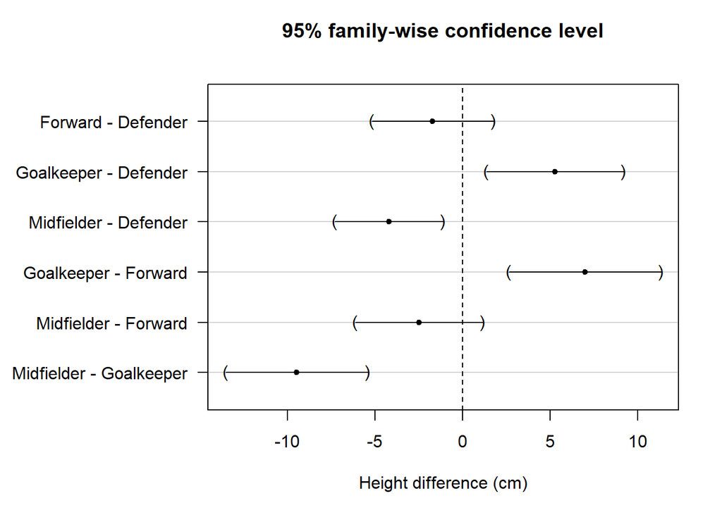

```r
par(mar = c(5, 10, 4, 2)+0.1)
HBW.comp %>% plot(xlab = "Height difference (cm)")
```

```r
par(mar = c(5, 10, 4, 2)+0.1)
```

### 3. Сравнение с ранее полученными выводами

В результате выполнения анализа методом Хоторна-Бретца-Вестфалла был получен аналогичный результат.

### 4. Дисперсионный анализ и постхок процедура Хоторна-Бретца-Вестфалла

*Для того, чтобы выяснить и описать наличие связи между ростом футболиста и страной, за которую он играет. Опишите и интерпретируйте полученные результаты.*

### Сводная статистика:

```r
soccer_wrk %>%
    group_by(Nationality) %>%
    summarise(
        count_position = n(),
        mean_time = mean(Height, na.rm = TRUE),
        sd_time = sd(Height, na.rm = TRUE)
    )
```

```
## # A tibble: 5 × 4
##   Nationality count_position mean_time sd_time
##   <fct>                <int>     <dbl>   <dbl>
## 1 Argentinian             15      183.    6.36
## 2 English                 27      184.    6.99
## 3 German                  25      182.    8.05
## 4 Italian                 33      183.    5.03
## 5 Spanish                 50      181.    6.49
```

### Box-plot для визуальной оценки данных

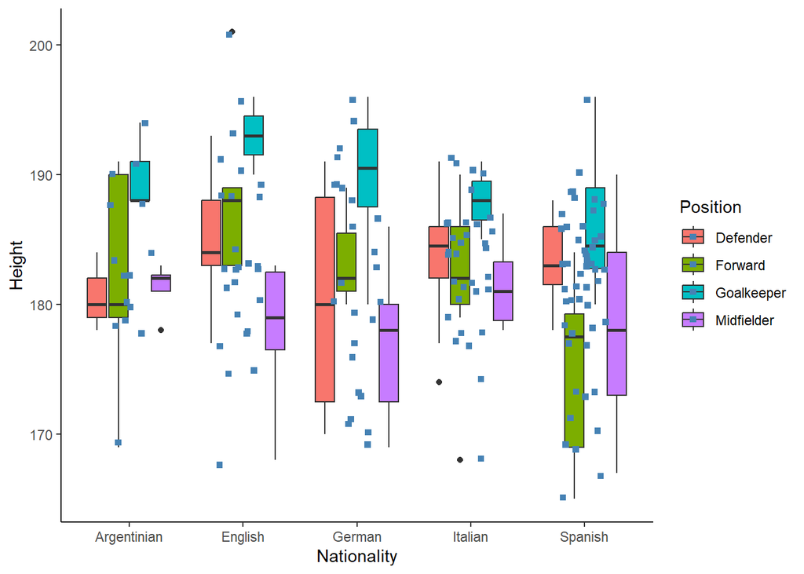

```r
ggplot(soccer_wrk, aes(x = Nationality, y = Height, fill = Position)) +
    geom_boxplot() +
    geom_jitter(shape = 15,
        color = "steelblue",
        position = position_jitter(0.21)) +
    theme_classic()
```

### One-way ANOVA

*Метод:* дисперсионный анализ.

*Гипотезы:*  
- H0: средние между группами идентичны  
- H1: среднее значение по крайней мере для одной группы отличается

```r
anova_one_way <- aov(Height ~ Nationality, data = soccer_wrk)
summary(anova_one_way)
```

```
##              Df Sum Sq Mean Sq F value Pr(>F)
## Nationality   4    164   41.03    0.95  0.437
## Residuals   145   6263   43.19
```

**Вывод:**  
Отсутствует статистическая разница между группами.

### Анализ методом Хоторна-Бретца-Вестфалла

```r
#Tukey сигнализирует, что мы хотим сравнить каждую группу с каждой. Анализ выполняется не методом Тьюки, а методом Хоторна-Бретца-Вестфалла!

m0 <- lm(Height ~ Nationality, data = soccer_wrk)
HBW.comp <- m0 %>%  glht(linfct = mcp(Nationality = "Tukey"))


HBW.comp %>% summary()
```

```
##
##   Simultaneous Tests for General Linear Hypotheses
##
## Multiple Comparisons of Means: Tukey Contrasts
##
##
## Fit: lm(formula = Height ~ Nationality, data = soccer_wrk)
##
## Linear Hypotheses:
##                            Estimate Std. Error t value Pr(>|t|)
## English - Argentinian == 0  0.71111    2.11643   0.336    0.997
## German - Argentinian == 0  -1.14667    2.14645  -0.534    0.983
## Italian - Argentinian == 0  0.08485    2.04656   0.041    1.000
## Spanish - Argentinian == 0 -1.94667    1.93478  -1.006    0.849
## German - English == 0      -1.85778    1.82413  -1.018    0.844
## Italian - English == 0     -0.62626    1.70546  -0.367    0.996
## Spanish - English == 0     -2.65778    1.56958  -1.693    0.436
## Italian - German == 0       1.23152    1.74258   0.707    0.954
## Spanish - German == 0      -0.80000    1.60984  -0.497    0.987
## Spanish - Italian == 0     -2.03152    1.47402  -1.378    0.638
## (Adjusted p values reported -- single-step method)
```

*Вывод:* значимые различия не наблюдаются.

### Доверительные интервалы

```r
HBW.comp %>% confint()
```

```
##
##   Simultaneous Confidence Intervals
##
## Multiple Comparisons of Means: Tukey Contrasts
##
##
## Fit: lm(formula = Height ~ Nationality, data = soccer_wrk)
##
## Quantile = 2.7534
## 95% family-wise confidence level
##
##
## Linear Hypotheses:
##                            Estimate lwr      upr
## English - Argentinian == 0  0.71111 -5.11632  6.53854
## German - Argentinian == 0  -1.14667 -7.05676  4.76342
## Italian - Argentinian == 0  0.08485 -5.55020  5.71990
## Spanish - Argentinian == 0 -1.94667 -7.27395  3.38062
## German - English == 0      -1.85778 -6.88039  3.16483
## Italian - English == 0     -0.62626 -5.32214  4.06961
## Spanish - English == 0     -2.65778 -6.97951  1.66396
## Italian - German == 0       1.23152 -3.56656  6.02959
## Spanish - German == 0      -0.80000 -5.23257  3.63257
## Spanish - Italian == 0     -2.03152 -6.09012  2.02709
```

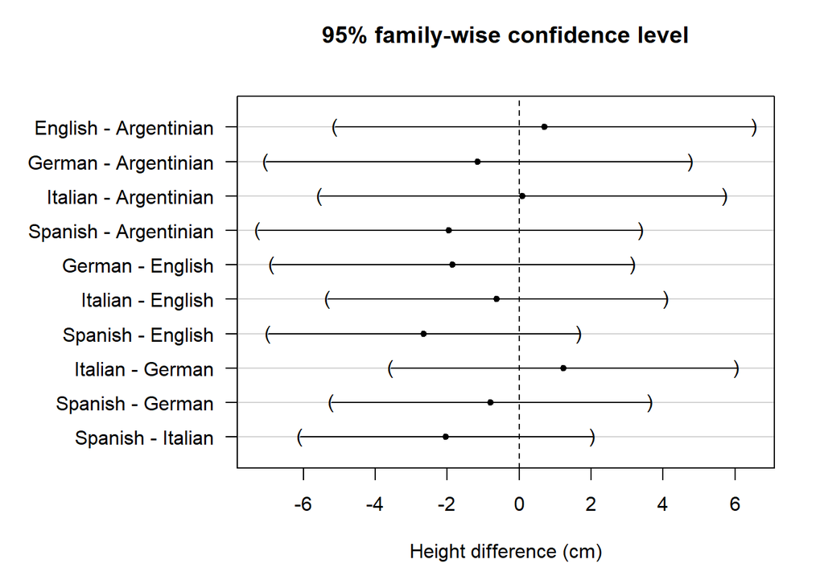

```r
par(mar = c(5, 10, 4, 2)+0.1)
HBW.comp %>% plot(xlab = "Height difference (cm)")
```

```r
par(mar = c(5, 10, 4, 2)+0.1)
```

## Общий вывод

Связь между ростом футболиста и страной отсутсвует.